# Diabetes_Analysis

## Diabetes 130-US Hospitals for Years 1999-2008

Link to Dataset: https://archive.ics.uci.edu/dataset/296/diabetes+130-us+hospitals+for+years+1999-2008

```python
# Import Needed Library
import pandas as pd
import numpy as np
import matplotlib.pyplot as plt
import seaborn as sns

# Import SMOTE Library
from imblearn.over_sampling import SMOTE
from imblearn.under_sampling import RandomUnderSampler
from imblearn.pipeline import Pipeline
```

```python
# Read the csv file.
df = pd.read_csv('data/diabetic_data.csv', na_values=['NaN', 'NULL'], keep_default_na=False)
df.head()
```

|  | encounter_id | patient_nbr | race | gender | age | weight | admission_type_id | discharge_disposition_id | admission_source_id | time_in_hospital | ... | citoglipton | insulin | glyburide-metformin | glipizide-metformin | glimepiride-pioglitazone | metformin-rosiglitazone | metformin-pioglitazone | change | diabetesMed | readmitted |
| --- | --- | --- | --- | --- | --- | --- | --- | --- | --- | --- | --- | --- | --- | --- | --- | --- | --- | --- | --- | --- | --- |
| 0 | 2278392 | 8222157 | Caucasian | Female | [0-10) | ? | 6 | 25 | 1 | 1 | ... | No | No | No | No | No | No | No | No | No | NO |
| 1 | 149190 | 55629189 | Caucasian | Female | [10-20) | ? | 1 | 1 | 7 | 3 | ... | No | Up | No | No | No | No | No | Ch | Yes | >30 |
| 2 | 64410 | 86047875 | AfricanAmerican | Female | [20-30) | ? | 1 | 1 | 7 | 2 | ... | No | No | No | No | No | No | No | No | Yes | NO |
| 3 | 500364 | 82442376 | Caucasian | Male | [30-40) | ? | 1 | 1 | 7 | 2 | ... | No | Up | No | No | No | No | No | Ch | Yes | NO |
| 4 | 16680 | 42519267 | Caucasian | Male | [40-50) | ? | 1 | 1 | 7 | 1 | ... | No | Steady | No | No | No | No | No | Ch | Yes | NO |

5 rows × 50 columns

## Dataset Level Analysis

```python
df.info()
```

```
<class 'pandas.core.frame.DataFrame'>
RangeIndex: 101766 entries, 0 to 101765
Data columns (total 50 columns):
 #   Column                    Non-Null Count   Dtype
---  ------                    --------------   -----
 0   encounter_id              101766 non-null  int64
 1   patient_nbr               101766 non-null  int64
 2   race                      101766 non-null  object
 3   gender                    101766 non-null  object
 4   age                       101766 non-null  object
 5   weight                    101766 non-null  object
 6   admission_type_id         101766 non-null  int64
 7   discharge_disposition_id  101766 non-null  int64
 8   admission_source_id       101766 non-null  int64
 9   time_in_hospital          101766 non-null  int64
```

[output cut: 42 more lines]

```python
# Understanding unique values in each columns
for column in df.columns:
    unique_values = df[column].unique()
    print(f"Unique values in column {column}: {unique_values}")
```

[output not shown]

```python
# Replace '?' with NaN
df.replace('?', np.nan, inplace=True)
df.head()
```

|  | encounter_id | patient_nbr | race | gender | age | weight | admission_type_id | discharge_disposition_id | admission_source_id | time_in_hospital | ... | citoglipton | insulin | glyburide-metformin | glipizide-metformin | glimepiride-pioglitazone | metformin-rosiglitazone | metformin-pioglitazone | change | diabetesMed | readmitted |
| --- | --- | --- | --- | --- | --- | --- | --- | --- | --- | --- | --- | --- | --- | --- | --- | --- | --- | --- | --- | --- | --- |
| 0 | 2278392 | 8222157 | Caucasian | Female | [0-10) | NaN | 6 | 25 | 1 | 1 | ... | No | No | No | No | No | No | No | No | No | NO |
| 1 | 149190 | 55629189 | Caucasian | Female | [10-20) | NaN | 1 | 1 | 7 | 3 | ... | No | Up | No | No | No | No | No | Ch | Yes | >30 |
| 2 | 64410 | 86047875 | AfricanAmerican | Female | [20-30) | NaN | 1 | 1 | 7 | 2 | ... | No | No | No | No | No | No | No | No | Yes | NO |
| 3 | 500364 | 82442376 | Caucasian | Male | [30-40) | NaN | 1 | 1 | 7 | 2 | ... | No | Up | No | No | No | No | No | Ch | Yes | NO |
| 4 | 16680 | 42519267 | Caucasian | Male | [40-50) | NaN | 1 | 1 | 7 | 1 | ... | No | Steady | No | No | No | No | No | Ch | Yes | NO |

5 rows × 50 columns

```python
# Missing values

# Calculate the number of missing values per column
missing_values = df.isnull().sum()

# Filter columns with missing values and sort them in descending order
columns_with_missing = missing_values[missing_values > 0].sort_values(ascending=False)

# Calculate the percentage of missing values
total_records = df.shape[0]
percent_missing = (columns_with_missing / total_records) * 100

# Create a DataFrame to display both missing values and their percentages
missing_df = pd.DataFrame({
    'Missing Values': columns_with_missing,
    'Percent Missing': percent_missing.map('{:.2f}%'.format)
})

# Display the DataFrame
missing_df
```

|  | Missing Values | Percent Missing |
| --- | --- | --- |
| weight | 98569 | 96.86% |
| medical_specialty | 49949 | 49.08% |
| payer_code | 40256 | 39.56% |
| race | 2273 | 2.23% |
| diag_3 | 1423 | 1.40% |
| diag_2 | 358 | 0.35% |
| diag_1 | 21 | 0.02% |

In this iteration,

- The top 3 columns with most missing values - 'weight', 'medical_specialty', 'payer_code' - can be dropped.
- For the other columns with missing values - 'race', 'diag_3', 'diag_2','diag_1' - the rows with missing values will be removed.

In future iteration, missing values can be handled differently to identify imporvements in the model

```python
# Drop the specific columns with highest missing values
df = df.drop(columns=['weight', 'medical_specialty', 'payer_code'])
df.head()
```

|  | encounter_id | patient_nbr | race | gender | age | admission_type_id | discharge_disposition_id | admission_source_id | time_in_hospital | num_lab_procedures | ... | citoglipton | insulin | glyburide-metformin | glipizide-metformin | glimepiride-pioglitazone | metformin-rosiglitazone | metformin-pioglitazone | change | diabetesMed | readmitted |
| --- | --- | --- | --- | --- | --- | --- | --- | --- | --- | --- | --- | --- | --- | --- | --- | --- | --- | --- | --- | --- | --- |
| 0 | 2278392 | 8222157 | Caucasian | Female | [0-10) | 6 | 25 | 1 | 1 | 41 | ... | No | No | No | No | No | No | No | No | No | NO |
| 1 | 149190 | 55629189 | Caucasian | Female | [10-20) | 1 | 1 | 7 | 3 | 59 | ... | No | Up | No | No | No | No | No | Ch | Yes | >30 |
| 2 | 64410 | 86047875 | AfricanAmerican | Female | [20-30) | 1 | 1 | 7 | 2 | 11 | ... | No | No | No | No | No | No | No | No | Yes | NO |
| 3 | 500364 | 82442376 | Caucasian | Male | [30-40) | 1 | 1 | 7 | 2 | 44 | ... | No | Up | No | No | No | No | No | Ch | Yes | NO |
| 4 | 16680 | 42519267 | Caucasian | Male | [40-50) | 1 | 1 | 7 | 1 | 51 | ... | No | Steady | No | No | No | No | No | Ch | Yes | NO |

5 rows × 47 columns

```python
# Drop rows where 'race', 'diag_3', 'diag_2','diag_1' are missing since the missing represents <3% of overall dataset
df_cleaned = df.dropna(subset=['race', 'diag_3', 'diag_2','diag_1'])
df_cleaned
```

|  | encounter_id | patient_nbr | race | gender | age | admission_type_id | discharge_disposition_id | admission_source_id | time_in_hospital | num_lab_procedures | ... | citoglipton | insulin | glyburide-metformin | glipizide-metformin | glimepiride-pioglitazone | metformin-rosiglitazone | metformin-pioglitazone | change | diabetesMed | readmitted |
| --- | --- | --- | --- | --- | --- | --- | --- | --- | --- | --- | --- | --- | --- | --- | --- | --- | --- | --- | --- | --- | --- |
| 1 | 149190 | 55629189 | Caucasian | Female | [10-20) | 1 | 1 | 7 | 3 | 59 | ... | No | Up | No | No | No | No | No | Ch | Yes | >30 |
| 2 | 64410 | 86047875 | AfricanAmerican | Female | [20-30) | 1 | 1 | 7 | 2 | 11 | ... | No | No | No | No | No | No | No | No | Yes | NO |
| 3 | 500364 | 82442376 | Caucasian | Male | [30-40) | 1 | 1 | 7 | 2 | 44 | ... | No | Up | No | No | No | No | No | Ch | Yes | NO |
| 4 | 16680 | 42519267 | Caucasian | Male | [40-50) | 1 | 1 | 7 | 1 | 51 | ... | No | Steady | No | No | No | No | No | Ch | Yes | NO |
| 5 | 35754 | 82637451 | Caucasian | Male | [50-60) | 2 | 1 | 2 | 3 | 31 | ... | No | Steady | No | No | No | No | No | No | Yes | >30 |
| ... | ... | ... | ... | ... | ... | ... | ... | ... | ... | ... | ... | ... | ... | ... | ... | ... | ... | ... | ... | ... | ... |
| 101761 | 443847548 | 100162476 | AfricanAmerican | Male | [70-80) | 1 | 3 | 7 | 3 | 51 | ... | No | Down | No | No | No | No | No | Ch | Yes | >30 |
| 101762 | 443847782 | 74694222 | AfricanAmerican | Female | [80-90) | 1 | 4 | 5 | 5 | 33 | ... | No | Steady | No | No | No | No | No | No | Yes | NO |
| 101763 | 443854148 | 41088789 | Caucasian | Male | [70-80) | 1 | 1 | 7 | 1 | 53 | ... | No | Down | No | No | No | No | No | Ch | Yes | NO |
| 101764 | 443857166 | 31693671 | Caucasian | Female | [80-90) | 2 | 3 | 7 | 10 | 45 | ... | No | Up | No | No | No | No | No | Ch | Yes | NO |
| 101765 | 443867222 | 175429310 | Caucasian | Male | [70-80) | 1 | 1 | 7 | 6 | 13 | ... | No | No | No | No | No | No | No | No | No | NO |

98053 rows × 47 columns

```python
# Check Missing values again

# Calculate the number of missing values per column
missing_values = df_cleaned.isnull().sum()

# Filter columns with missing values and sort them in descending order
columns_with_missing = missing_values[missing_values > 0].sort_values(ascending=False)

# Calculate the percentage of missing values
total_records = df_cleaned.shape[0]
percent_missing = (columns_with_missing / total_records) * 100

# Create a DataFrame to display both missing values and their percentages
missing_df = pd.DataFrame({
    'Missing Values': columns_with_missing,
    'Percent Missing': percent_missing.map('{:.2f}%'.format)
})

# Display the DataFrame
missing_df
```

|  | Missing Values | Percent Missing |
| --- | --- | --- |

Hence there are no missing values in the dataset now

## Exploratory Data Analysis

```python
# Renaming the dataframe name
df = df_cleaned.copy()
```

```python
# Check if there are any Duplicate records in the whole dataset
duplicate_count = df.duplicated().sum()
print("Number of duplicate rows:", duplicate_count)
```

```
Number of duplicate rows: 0
```

### Categorical Variable Analysis

```python
# Total Number of patients in the dataset

# Count the number of unique patient IDs
unique_patient_count = df['patient_nbr'].nunique()
print("Number of unique patients:", unique_patient_count)
```

```
Number of unique patients: 68630
```

```
Distribution of the count of encounters per patient:
encounter_id
1     52350
2     10104
3      3230
4      1385
5       710
6       336
7       202
8       108
9        71
10       38
11       21
12       20
13       13
14        5
15        8
16        4
17        3
18        6
19        4
20        5
21        1
22        2
23        3
39        1
Name: count, dtype: int64
```

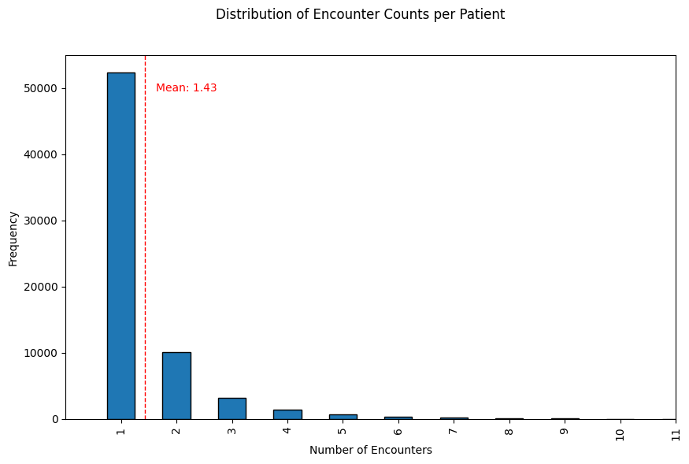

```python
# Number of encounters/visit per patients and its distribution

# Count the number of encounters per patient
encounter_counts = df.groupby('patient_nbr')['encounter_id'].count()

# Print the distribution of the count of encounters per patient
encounter_distribution = encounter_counts.value_counts().sort_index()
print("Distribution of the count of encounters per patient:")
print(encounter_distribution)

# Plot the distribution of encounter counts

# Plot the distribution of encounter counts
plt.figure(figsize=(10, 6))
encounter_distribution.plot(kind='bar', edgecolor='black')

# Plot the mean value
mean_value = encounter_counts.mean()
plt.axvline(mean_value - 1, color='r', linestyle='dashed', linewidth=1)  # -1 to align with the bar positions
plt.text(mean_value - 1 + 0.2, plt.ylim()[1] * 0.9, f'Mean: {mean_value:.2f}', color='r')

# Set x-axis range
plt.xlim(-1, 10)

# Titles and labels
plt.suptitle('Distribution of Encounter Counts per Patient')
plt.xlabel('Number of Encounters')
plt.ylabel('Frequency')

plt.show()
```

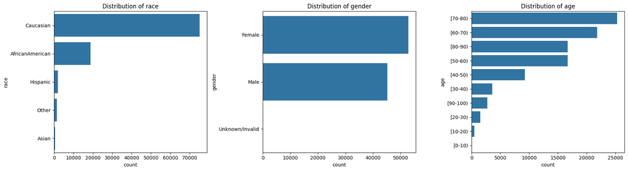

|  | race | gender | age |
| --- | --- | --- | --- |
| count | 98053 | 98053 | 98053 |
| unique | 5 | 3 | 10 |
| top | Caucasian | Female | [70-80) |
| freq | 75079 | 52833 | 25306 |

```python
# Analysis of demographic features

# Define the features to plot
features = ['race', 'gender', 'age']

# Create a figure with 3 subplots arranged in a row
fig, axes = plt.subplots(1, 3, figsize=(18, 5))

# Loop through each feature and corresponding axis
for feature, ax in zip(features, axes):
    sns.countplot(y=df[feature], order=df[feature].value_counts().index, ax=ax)
    ax.set_title(f'Distribution of {feature}')

# Adjust layout to prevent overlap
plt.tight_layout()

# Show the plot
plt.show()


# Summary statistics for demographic features
df[['race', 'gender', 'age']].describe(include='all')
```

**Analysis of demographic variables:**

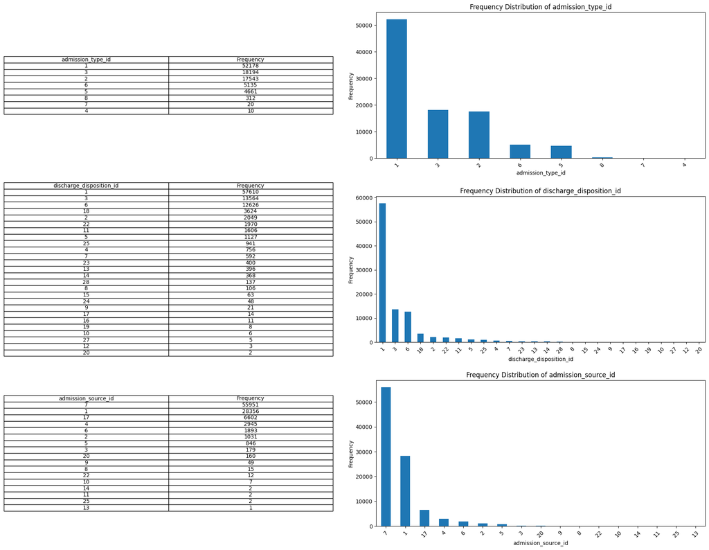

```python
# Categorical variables related to admissiong info for EDA
variables = ['admission_type_id', 'discharge_disposition_id', 'admission_source_id']


# Set up the matplotlib figure and axes
fig, axes = plt.subplots(nrows=len(variables), ncols=2, figsize=(20, 5 * len(variables)))
fig.tight_layout(pad=5.0)

# Perform EDA for each variable
for i, var in enumerate(variables):
    # Get the unique values and their counts
    var_counts = df[var].value_counts()

    # Display the unique values and counts as a table
    ax_table = axes[i, 0]
    ax_table.axis('tight')
    ax_table.axis('off')
    table_data = pd.DataFrame(var_counts).reset_index()
    table_data.columns = [var, 'Frequency']
    ax_table.table(cellText=table_data.values, colLabels=table_data.columns, cellLoc='center', loc='center')

    # Plot a bar chart for the variable
    ax_bar = axes[i, 1]
    var_counts.plot(kind='bar', ax=ax_bar)
    ax_bar.set_title(f'Frequency Distribution of {var}')
    ax_bar.set_xlabel(var)
    ax_bar.set_ylabel('Frequency')
    ax_bar.set_xticklabels(ax_bar.get_xticklabels(), rotation=45)

plt.show()
```

All of the above variables have multiple possible values, making one-hot encoding an impractical approach. Therefore, we need to transform or group these variables before using them in modeling.

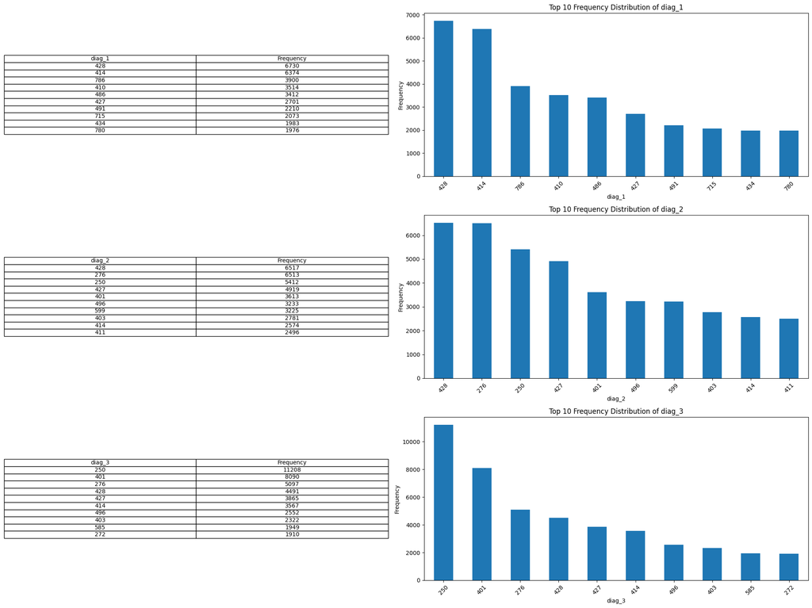

```python
# Analysis of Diagnosis variables
nominal_vars = ['diag_1', 'diag_2', 'diag_3']

# Set up the matplotlib figure and axes
fig, axes = plt.subplots(nrows=len(nominal_vars), ncols=2, figsize=(20, 5 * len(nominal_vars)))
fig.tight_layout(pad=5.0)

# Perform EDA for nominal variables
for i, var in enumerate(nominal_vars):
    # Get the unique values and their counts
    var_counts = df[var].value_counts()

    # Determine the top categories (e.g., top 10)
    top_var_counts = var_counts.head(10)

    # Display the unique values and counts as a table
    ax_table = axes[i, 0]
    ax_table.axis('tight')
    ax_table.axis('off')
    table_data = pd.DataFrame(top_var_counts).reset_index()
    table_data.columns = [var, 'Frequency']
    ax_table.table(cellText=table_data.values, colLabels=table_data.columns, cellLoc='center', loc='center')

    # Plot a bar chart for the variable
    ax_bar = axes[i, 1]
    top_var_counts.plot(kind='bar', ax=ax_bar)
    ax_bar.set_title(f'Top 10 Frequency Distribution of {var}')
    ax_bar.set_xlabel(var)
    ax_bar.set_ylabel('Frequency')
    ax_bar.set_xticklabels(ax_bar.get_xticklabels(), rotation=45)

# Adjust layout
plt.tight_layout()

# Show plots
plt.show()
```

Similar to the admission info variable, the diagnosis variables use ICD9 mapping. Therefore, we need to group them before performing one-hot encoding.

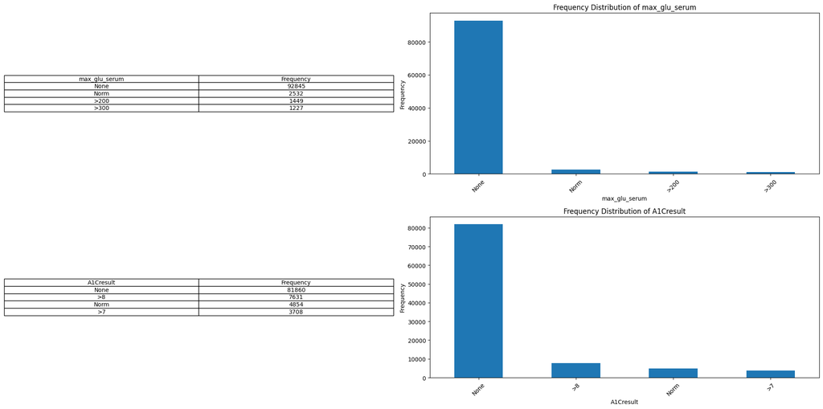

```python
# Analysis of Glucose variables

nominal_vars = ['max_glu_serum', 'A1Cresult']

# Set up the matplotlib figure and axes
fig, axes = plt.subplots(nrows=len(nominal_vars), ncols=2, figsize=(20, 5 * len(nominal_vars)))
fig.tight_layout(pad=5.0)

# Perform EDA for nominal variables
for i, var in enumerate(nominal_vars):
    # Get the unique values and their counts
    var_counts = df[var].value_counts()

    # Determine the top categories (e.g., top 10 for diagnosis variables)
    if 'Diagnosis' in var:
        top_var_counts = var_counts.head(10)
    else:
        top_var_counts = var_counts

    # Display the unique values and counts as a table
    ax_table = axes[i, 0]
    ax_table.axis('tight')
    ax_table.axis('off')
    table_data = pd.DataFrame(top_var_counts).reset_index()
    table_data.columns = [var, 'Frequency']
    ax_table.table(cellText=table_data.values, colLabels=table_data.columns, cellLoc='center', loc='center')

    # Plot a bar chart for the variable
    ax_bar = axes[i, 1]
    top_var_counts.plot(kind='bar', ax=ax_bar)
    ax_bar.set_title(f'Frequency Distribution of {var}')
    ax_bar.set_xlabel(var)
    ax_bar.set_ylabel('Frequency')
    ax_bar.set_xticklabels(ax_bar.get_xticklabels(), rotation=45)

# Adjust layout
plt.tight_layout()

# Show plots
plt.show()
```

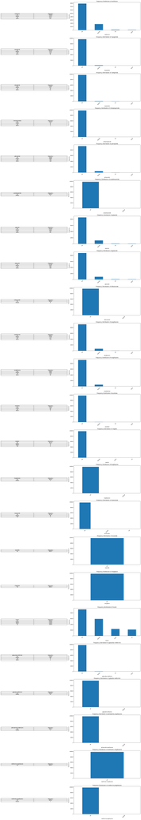

```python
# Analysis of All Medication variables

medication_vars = [
    'metformin', 'repaglinide', 'nateglinide', 'chlorpropamide', 'glimepiride',
    'acetohexamide', 'glipizide', 'glyburide', 'tolbutamide', 'pioglitazone',
    'rosiglitazone', 'acarbose', 'miglitol', 'troglitazone', 'tolazamide',
    'examide', 'citoglipton', 'insulin', 'glyburide-metformin', 'glipizide-metformin',
    'glimepiride-pioglitazone', 'metformin-rosiglitazone', 'metformin-pioglitazone'
]

# Set up the matplotlib figure and axes
fig, axes = plt.subplots(nrows=len(medication_vars), ncols=2, figsize=(20, 5 * len(medication_vars)))
fig.tight_layout(pad=5.0)

# Perform EDA for medication variables
for i, var in enumerate(medication_vars):
    # Get the unique values and their counts
    var_counts = df[var].value_counts()

    # Display the unique values and counts as a table
    ax_table = axes[i, 0]
    ax_table.axis('tight')
    ax_table.axis('off')
    table_data = pd.DataFrame(var_counts).reset_index()
    table_data.columns = [var, 'Frequency']
    ax_table.table(cellText=table_data.values, colLabels=table_data.columns, cellLoc='center', loc='center')

    # Plot a bar chart for the variable
    ax_bar = axes[i, 1]
    var_counts.plot(kind='bar', ax=ax_bar)
    ax_bar.set_title(f'Frequency Distribution of {var}')
    ax_bar.set_xlabel(var)
    ax_bar.set_ylabel('Frequency')
    ax_bar.set_xticklabels(ax_bar.get_xticklabels(), rotation=45)

# Adjust layout
plt.tight_layout()

# Show plots
plt.show()
```

Only insulin shows high variance among all the medications

## Numeric variable Analysis

```
Summary statistics for numeric variables:
        num_lab_procedures  num_procedures  num_medications  number_outpatient  \
count        98053.000000    98053.000000     98053.000000       98053.000000
mean            43.148073        1.350749        16.119650           0.376378
std             19.712033        1.708506         8.108476           1.283359
min              1.000000        0.000000         1.000000           0.000000
25%             31.000000        0.000000        11.000000           0.000000
50%             44.000000        1.000000        15.000000           0.000000
75%             57.000000        2.000000        20.000000           0.000000
max            132.000000        6.000000        81.000000          42.000000

       number_emergency  number_inpatient  number_diagnoses
count      98053.000000      98053.000000      98053.000000
mean           0.202462          0.646864          7.512060
std            0.942892          1.271020          1.832497
min            0.000000          0.000000          3.000000
25%            0.000000          0.000000          6.000000
50%            0.000000          0.000000          8.000000
75%            0.000000          1.000000          9.000000
max           76.000000         21.000000         16.000000
```

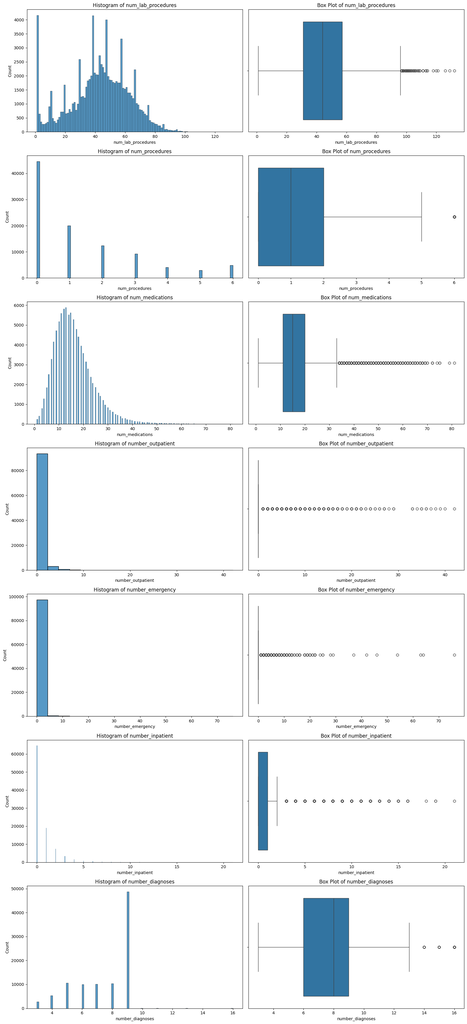

```python
import matplotlib.pyplot as plt
import seaborn as sns
import pandas as pd

# Define the numeric variables
numeric_vars = ['num_lab_procedures', 'num_procedures', 'num_medications',
                'number_outpatient', 'number_emergency', 'number_inpatient', 'number_diagnoses']

# Calculate summary statistics for all numeric variables and concatenate them into a single DataFrame
summary_stats = pd.concat([df[var].describe() for var in numeric_vars], axis=1)
summary_stats.columns = numeric_vars

# Display the summary statistics in one table
print("Summary statistics for numeric variables:\n", summary_stats)

# Set up the matplotlib figure and axes
fig, axes = plt.subplots(nrows=len(numeric_vars), ncols=2, figsize=(16, 5 * len(numeric_vars)))
fig.tight_layout(pad=5.0)

# Perform EDA for numeric variables
for i, var in enumerate(numeric_vars):
    # Histogram
    sns.histplot(df[var], kde=False, ax=axes[i, 0])
    axes[i, 0].set_title(f'Histogram of {var}')

    # Box Plot
    sns.boxplot(x=df[var], ax=axes[i, 1])
    axes[i, 1].set_title(f'Box Plot of {var}')

# Adjust layout
plt.tight_layout()

# Show plots
plt.show()
```

Almost all the variables above don't need any further transformations for this iteration. Therefore, no modifications are required at this stage. We will assess if additional transformations are needed in the next round of model iteration.

### Numeric - Continous Variable Analysis

Variable - Time in Hospital

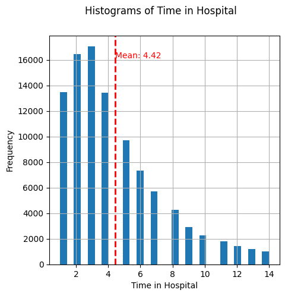

```python
# Assuming df is your DataFrame
mean_time_in_hospital = df['time_in_hospital'].mean()

# Plot histogram
df['time_in_hospital'].hist(bins=30, figsize=(5, 5))
plt.suptitle('Histograms of Time in Hospital')
plt.xlabel('Time in Hospital')
plt.ylabel('Frequency')

# Plot mean line
plt.axvline(mean_time_in_hospital, color='r', linestyle='dashed', linewidth=2)
plt.text(mean_time_in_hospital, plt.ylim()[1]*0.9, f'Mean: {mean_time_in_hospital:.2f}', color='r')

# Show plot
plt.show()
```

## Target Variable - Readmission - Analysis

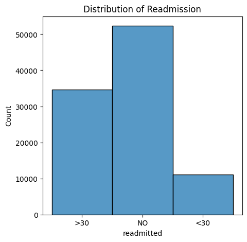

| readmitted | Count | Proportion (%) |
| --- | --- | --- |
| NO | 52338 | 53.38% |
| >30 | 34649 | 35.34% |
| <30 | 11066 | 11.29% |

```python
# Distribution of Readmission
plt.figure(figsize=(5, 5))
sns.histplot(df['readmitted'])
plt.title('Distribution of Readmission')
plt.show()

# Calculate frequency and proportion
readmitted_counts = df['readmitted'].value_counts()
# readmitted_proportions = df['readmitted'].value_counts(normalize=True)
readmitted_proportions = df['readmitted'].value_counts(normalize=True) * 100

readmitted_summary = pd.DataFrame({
    'Count': readmitted_counts,
    'Proportion (%)': readmitted_proportions.map('{:.2f}%'.format)
})

readmitted_summary
```

There is an imbalance in the target variable 'readmitted', which needs to be addressed during data cleaning.

# Feature Engineering and Transformations

### Data types

From above EDA, we can understand that the dataset has the following types of variables:

Nominal - race, gender, admission type, discharge disposition, admission source, medical specialty, change of medications, diabetes medications.

Ordinal - glucose serum test result, A1c test result, 24 medication features.

Numerical - payer code, diagnosis 1, diagnosis 2, diagnosis 3, encounter ID, patient number, weight, time in hospital, number of lab procedures, number of procedures, number of medications, number of outpatient visits, number of emergency visits, number of impatient visits, number of diagnoses.

Interval - Age

## Nominal Variable

```python
columns_to_check = [
    'race', 'gender', 'admission_type_id', 'discharge_disposition_id',
    'admission_source_id', 'medical_specialty', 'change', 'diabetesMed'
]

# Iterate through the columns and print unique values
for column in columns_to_check:
    if column in df_cleaned.columns:
        unique_values = df_cleaned[column].unique()
        print(f"Unique values in {column}: {unique_values}\n")
```

```
Unique values in race: ['Caucasian' 'AfricanAmerican' 'Other' 'Asian' 'Hispanic']

Unique values in gender: ['Female' 'Male' 'Unknown/Invalid']

Unique values in admission_type_id: [1 2 3 6 4 5 8 7]

Unique values in discharge_disposition_id: [ 1  3  6  2  5 11  7 25 10  4 14 18  8 13 12 16 17 22 23  9 20 15 24 28
 19 27]

Unique values in admission_source_id: [ 7  2  4  1  5  6 20  3 17  8  9 14 10 22 11 25 13]

Unique values in change: ['Ch' 'No']

Unique values in diabetesMed: ['Yes' 'No']
```

```python
# Perform one-hot encoding on the 'race','change', 'diabetesMed', 'gender' columns
df_encoded = pd.get_dummies(df_cleaned, columns=['race', 'change', 'diabetesMed','gender'])
df_encoded
```

|  | encounter_id | patient_nbr | age | admission_type_id | discharge_disposition_id | admission_source_id | time_in_hospital | num_lab_procedures | num_procedures | num_medications | ... | race_Caucasian | race_Hispanic | race_Other | change_Ch | change_No | diabetesMed_No | diabetesMed_Yes | gender_Female | gender_Male | gender_Unknown/Invalid |
| --- | --- | --- | --- | --- | --- | --- | --- | --- | --- | --- | --- | --- | --- | --- | --- | --- | --- | --- | --- | --- | --- |
| 1 | 149190 | 55629189 | [10-20) | 1 | 1 | 7 | 3 | 59 | 0 | 18 | ... | True | False | False | True | False | False | True | True | False | False |
| 2 | 64410 | 86047875 | [20-30) | 1 | 1 | 7 | 2 | 11 | 5 | 13 | ... | False | False | False | False | True | False | True | True | False | False |
| 3 | 500364 | 82442376 | [30-40) | 1 | 1 | 7 | 2 | 44 | 1 | 16 | ... | True | False | False | True | False | False | True | False | True | False |
| 4 | 16680 | 42519267 | [40-50) | 1 | 1 | 7 | 1 | 51 | 0 | 8 | ... | True | False | False | True | False | False | True | False | True | False |
| 5 | 35754 | 82637451 | [50-60) | 2 | 1 | 2 | 3 | 31 | 6 | 16 | ... | True | False | False | False | True | False | True | False | True | False |
| ... | ... | ... | ... | ... | ... | ... | ... | ... | ... | ... | ... | ... | ... | ... | ... | ... | ... | ... | ... | ... | ... |
| 101761 | 443847548 | 100162476 | [70-80) | 1 | 3 | 7 | 3 | 51 | 0 | 16 | ... | False | False | False | True | False | False | True | False | True | False |
| 101762 | 443847782 | 74694222 | [80-90) | 1 | 4 | 5 | 5 | 33 | 3 | 18 | ... | False | False | False | False | True | False | True | True | False | False |
| 101763 | 443854148 | 41088789 | [70-80) | 1 | 1 | 7 | 1 | 53 | 0 | 9 | ... | True | False | False | True | False | False | True | False | True | False |
| 101764 | 443857166 | 31693671 | [80-90) | 2 | 3 | 7 | 10 | 45 | 2 | 21 | ... | True | False | False | True | False | False | True | True | False | False |
| 101765 | 443867222 | 175429310 | [70-80) | 1 | 1 | 7 | 6 | 13 | 3 | 3 | ... | True | False | False | False | True | True | False | False | True | False |

98053 rows × 55 columns

```python
# Admission type
    #Import the mapping for this column and clean it for further processing

# ids_mapping = pd.read_csv('data/IDS_mapping.csv')
ids_mapping = pd.read_csv('data/IDS_mapping.csv', na_values=['NaN'], keep_default_na=False)

# admission_type_id: First 8 rows
admission_type_mapping = ids_mapping.iloc[0:8].reset_index(drop=True)
# Rename the description columns to avoid conflicts
admission_type_mapping.columns = ['admission_type_id', 'admission_type_description']
# convert the main column to numeric
admission_type_mapping['admission_type_id'] = pd.to_numeric(admission_type_mapping['admission_type_id'], errors='coerce')

# discharge_disposition_id: Next set of rows
discharge_disposition_mapping = ids_mapping.iloc[10:40].reset_index(drop=True)
# Rename the description columns to avoid conflicts
discharge_disposition_mapping.columns = ['discharge_disposition_id', 'discharge_disposition_description']
# convert the main column to numeric
discharge_disposition_mapping['discharge_disposition_id'] = pd.to_numeric(discharge_disposition_mapping['discharge_disposition_id'], errors='coerce')

# admission_source_id: Following set of rows
admission_source_mapping = ids_mapping.iloc[42:].reset_index(drop=True)
# Rename the description columns to avoid conflicts
admission_source_mapping.columns = ['admission_source_id', 'admission_source_description']
# convert the main column to numeric
admission_source_mapping['admission_source_id'] = pd.to_numeric(admission_source_mapping['admission_source_id'], errors='coerce')
```

```python
# Map value of 'admission_type' column -
    # Emergency to 'Emergency' ; All other values to 'Other'.
    # Emergency admission shows a critical condition of a patient, thus differs from the other admission types.

print("\033[1m\033[4mBefore grouping:\033[0m")
print(admission_type_mapping)

# Define a function to map values
def map_admission_type(value):
    if value == 'Emergency':
        return 'Emergency'
    else:
        return 'Other'

# Apply the function to the 'admission_type' column
admission_type_mapping['admission_type_description'] = admission_type_mapping['admission_type_description'].map(map_admission_type)

# Display the resulting DataFrame
print("\033[1m\033[4mAfter grouping:\033[0m")
admission_type_mapping
```

```
Before grouping:
   admission_type_id admission_type_description
0                  1                  Emergency
1                  2                     Urgent
2                  3                   Elective
3                  4                    Newborn
4                  5              Not Available
5                  6                       NULL
6                  7              Trauma Center
7                  8                 Not Mapped
After grouping:
```

|  | admission_type_id | admission_type_description |
| --- | --- | --- |
| 0 | 1 | Emergency |
| 1 | 2 | Other |
| 2 | 3 | Other |
| 3 | 4 | Other |
| 4 | 5 | Other |
| 5 | 6 | Other |
| 6 | 7 | Other |
| 7 | 8 | Other |

```python
# Map value of 'admission_source' column -
    # Emergency to 'Emergency' ; All other values to 'Other'
    # 3 types - 'Emergency room', 'transfer', and 'Other'

print("\033[1m\033[4mBefore grouping:\033[0m")
print(admission_source_mapping)

# Mapping dictionary
description_map = {
    ' Physician Referral': 'Other',
    'Clinic Referral': 'Other',
    'HMO Referral': 'Other',
    'Transfer from a hospital': 'Transfer',
    ' Transfer from a Skilled Nursing Facility (SNF)': 'Transfer',
    ' Transfer from another health care facility': 'Transfer',
    ' Emergency Room': 'Emergency Room',
    ' Court/Law Enforcement': 'Other',
    ' Not Available': 'Other',
    ' Transfer from critial access hospital': 'Transfer',
    'Normal Delivery': 'Other',
    ' Premature Delivery': 'Other',
    ' Sick Baby': 'Other',
    ' Extramural Birth': 'Other',
    'Not Available': 'Other',
    'NULL': 'Other',
    ' Transfer From Another Home Health Agency': 'Transfer',
    'Readmission to Same Home Health Agency': 'Other',
    ' Not Mapped': 'Other',
    'Unknown/Invalid': 'Other',
    ' Transfer from hospital inpt/same fac reslt in a sep claim': 'Transfer',
    ' Born inside this hospital': 'Other',
    ' Born outside this hospital': 'Other',
    ' Transfer from Ambulatory Surgery Center': 'Transfer',
    'Transfer from Hospice': 'Transfer'
}

# Apply the mapping
admission_source_mapping['admission_source_description'] = admission_source_mapping['admission_source_description'].map(description_map)

# Display the resulting DataFrame
print("\033[1m\033[4mAfter grouping:\033[0m")
admission_source_mapping
```

```
Before grouping:
    admission_source_id                       admission_source_description
0                     1                                 Physician Referral
1                     2                                    Clinic Referral
2                     3                                       HMO Referral
3                     4                           Transfer from a hospital
4                     5     Transfer from a Skilled Nursing Facility (SNF)
5                     6         Transfer from another health care facility
6                     7                                     Emergency Room
7                     8                              Court/Law Enforcement
8                     9                                      Not Available
9                    10              Transfer from critial access hospital
10                   11                                    Normal Delivery
11                   12                                 Premature Delivery
12                   13                                          Sick Baby
13                   14                                   Extramural Birth
14                   15                                      Not Available
15                   17                                               NULL
16                   18           Transfer From Another Home Health Agency
17                   19             Readmission to Same Home Health Agency
18                   20                                         Not Mapped
19                   21                                    Unknown/Invalid
20                   22   Transfer from hospital inpt/same fac reslt in...
21                   23                          Born inside this hospital
22                   24                         Born outside this hospital
23                   25            Transfer from Ambulatory Surgery Center
24                   26                              Transfer from Hospice
After grouping:
```

|  | admission_source_id | admission_source_description |
| --- | --- | --- |
| 0 | 1 | Other |
| 1 | 2 | Other |
| 2 | 3 | Other |
| 3 | 4 | Transfer |
| 4 | 5 | Transfer |
| 5 | 6 | Transfer |
| 6 | 7 | Emergency Room |
| 7 | 8 | Other |
| 8 | 9 | Other |
| 9 | 10 | Transfer |
| 10 | 11 | Other |
| 11 | 12 | Other |
| 12 | 13 | Other |
| 13 | 14 | Other |
| 14 | 15 | Other |
| 15 | 17 | Other |
| 16 | 18 | Transfer |
| 17 | 19 | Other |
| 18 | 20 | Other |
| 19 | 21 | Other |
| 20 | 22 | Transfer |
| 21 | 23 | Other |
| 22 | 24 | Other |
| 23 | 25 | Transfer |
| 24 | 26 | Transfer |

```python
# Map value of 'discharge_disposition' column -
    # 3 types - home, transfer, and the other discharge

print("\033[1m\033[4mBefore grouping:\033[0m")
print(discharge_disposition_mapping)

# Mapping dictionary
description_mapping = {
    'Discharged to home': 'Home',
    'Discharged/transferred to another short term hospital': 'Transfer',
    'Discharged/transferred to SNF': 'Transfer',
    'Discharged/transferred to ICF': 'Transfer',
    'Discharged/transferred to another type of inpatient care institution': 'Transfer',
    'Discharged/transferred to home with home health service': 'Home',
    'Left AMA': 'Other Discharge',
    'Discharged/transferred to home under care of Home IV provider': 'Home',
    'Admitted as an inpatient to this hospital': 'Other Discharge',
    'Neonate discharged to another hospital for neonatal aftercare': 'Transfer',
    'Expired': 'Other Discharge',
    'Still patient or expected to return for outpatient services': 'Other Discharge',
    'Hospice / home': 'Home',
    'Hospice / medical facility': 'Transfer',
    'Discharged/transferred within this institution to Medicare approved swing bed': 'Transfer',
    'Discharged/transferred/referred another institution for outpatient services': 'Transfer',
    'Discharged/transferred/referred to this institution for outpatient services': 'Transfer',
    'NULL': 'Other Discharge',
    'Expired at home. Medicaid only, hospice.': 'Home',
    'Expired in a medical facility. Medicaid only, hospice.': 'Transfer',
    'Expired, place unknown. Medicaid only, hospice.': 'Other Discharge',
    'Discharged/transferred to another rehab fac including rehab units of a hospital .': 'Transfer',
    'Discharged/transferred to a long term care hospital.': 'Transfer',
    'Discharged/transferred to a nursing facility certified under Medicaid but not certified under Medicare.': 'Transfer',
    'Not Mapped': 'Other Discharge',
    'Unknown/Invalid': 'Other Discharge',
    'Discharged/transferred to a federal health care facility.': 'Transfer',
    'Discharged/transferred/referred to a psychiatric hospital of psychiatric distinct part unit of a hospital': 'Transfer',
    'Discharged/transferred to a Critical Access Hospital (CAH).': 'Transfer',
    'Discharged/transferred to another Type of Health Care Institution not Defined Elsewhere': 'Transfer'
}

# Apply the mapping
discharge_disposition_mapping['discharge_disposition_description'] = discharge_disposition_mapping['discharge_disposition_description'].map(description_mapping)

# Display the resulting DataFrame
print("\033[1m\033[4mAfter grouping:\033[0m")
discharge_disposition_mapping
```

```
Before grouping:
    discharge_disposition_id  \
0                          1
1                          2
2                          3
3                          4
4                          5
5                          6
6                          7
7                          8
8                          9
9                         10
10                        11
11                        12
12                        13
```

[output cut: 50 more lines]

|  | discharge_disposition_id | discharge_disposition_description |
| --- | --- | --- |
| 0 | 1 | Home |
| 1 | 2 | Transfer |
| 2 | 3 | Transfer |
| 3 | 4 | Transfer |
| 4 | 5 | Transfer |
| 5 | 6 | Home |
| 6 | 7 | Other Discharge |
| 7 | 8 | Home |
| 8 | 9 | Other Discharge |
| 9 | 10 | Transfer |
| 10 | 11 | Other Discharge |
| 11 | 12 | Other Discharge |
| 12 | 13 | Home |
| 13 | 14 | Transfer |
| 14 | 15 | Transfer |
| 15 | 16 | Transfer |
| 16 | 17 | Transfer |
| 17 | 18 | Other Discharge |
| 18 | 19 | Home |
| 19 | 20 | Transfer |
| 20 | 21 | Other Discharge |
| 21 | 22 | Transfer |
| 22 | 23 | Transfer |
| 23 | 24 | Transfer |
| 24 | 25 | Other Discharge |
| 25 | 26 | Other Discharge |
| 26 | 30 | Transfer |
| 27 | 27 | Transfer |
| 28 | 28 | Transfer |
| 29 | 29 | Transfer |

```python
## Merge above three imported with the main DataFrame (assuming your main DataFrame is df_cleaned)
df_encoded_1 = pd.merge(df_encoded, admission_type_mapping, how='left', on='admission_type_id')
df_encoded_1 = pd.merge(df_encoded_1, discharge_disposition_mapping, how='left', on='discharge_disposition_id')
df_encoded_1 = pd.merge(df_encoded_1, admission_source_mapping, how='left', on='admission_source_id')

# Set option to display all columns
pd.set_option('display.max_columns', None)

# Display the resulting DataFrame
df_encoded_1.head()
```

|  | encounter_id | patient_nbr | age | admission_type_id | discharge_disposition_id | admission_source_id | time_in_hospital | num_lab_procedures | num_procedures | num_medications | number_outpatient | number_emergency | number_inpatient | diag_1 | diag_2 | diag_3 | number_diagnoses | max_glu_serum | A1Cresult | metformin | repaglinide | nateglinide | chlorpropamide | glimepiride | acetohexamide | glipizide | glyburide | tolbutamide | pioglitazone | … |
| --- | --- | --- | --- | --- | --- | --- | --- | --- | --- | --- | --- | --- | --- | --- | --- | --- | --- | --- | --- | --- | --- | --- | --- | --- | --- | --- | --- | --- | --- | --- |
| 0 | 149190 | 55629189 | [10-20) | 1 | 1 | 7 | 3 | 59 | 0 | 18 | 0 | 0 | 0 | 276 | 250.01 | 255 | 9 | None | None | No | No | No | No | No | No | No | No | No | No | … |
| 1 | 64410 | 86047875 | [20-30) | 1 | 1 | 7 | 2 | 11 | 5 | 13 | 2 | 0 | 1 | 648 | 250 | V27 | 6 | None | None | No | No | No | No | No | No | Steady | No | No | No | … |
| 2 | 500364 | 82442376 | [30-40) | 1 | 1 | 7 | 2 | 44 | 1 | 16 | 0 | 0 | 0 | 8 | 250.43 | 403 | 7 | None | None | No | No | No | No | No | No | No | No | No | No | … |
| 3 | 16680 | 42519267 | [40-50) | 1 | 1 | 7 | 1 | 51 | 0 | 8 | 0 | 0 | 0 | 197 | 157 | 250 | 5 | None | None | No | No | No | No | No | No | Steady | No | No | No | … |
| 4 | 35754 | 82637451 | [50-60) | 2 | 1 | 2 | 3 | 31 | 6 | 16 | 0 | 0 | 0 | 414 | 411 | 250 | 9 | None | None | No | No | No | No | No | No | No | No | No | No | … |

```python
# Perform one-hot encoding for admission_type_id, discharge_disposition_id, admission_source_id
df_encoded_2 = pd.get_dummies(df_encoded_1, columns=['admission_type_description', 'discharge_disposition_description', 'admission_source_description'])
df_encoded_2
```

|  | encounter_id | patient_nbr | age | admission_type_id | discharge_disposition_id | admission_source_id | time_in_hospital | num_lab_procedures | num_procedures | num_medications | number_outpatient | number_emergency | number_inpatient | diag_1 | diag_2 | diag_3 | number_diagnoses | max_glu_serum | A1Cresult | metformin | repaglinide | nateglinide | chlorpropamide | glimepiride | acetohexamide | glipizide | glyburide | tolbutamide | pioglitazone | … |
| --- | --- | --- | --- | --- | --- | --- | --- | --- | --- | --- | --- | --- | --- | --- | --- | --- | --- | --- | --- | --- | --- | --- | --- | --- | --- | --- | --- | --- | --- | --- |
| 0 | 149190 | 55629189 | [10-20) | 1 | 1 | 7 | 3 | 59 | 0 | 18 | 0 | 0 | 0 | 276 | 250.01 | 255 | 9 | None | None | No | No | No | No | No | No | No | No | No | No | … |
| 1 | 64410 | 86047875 | [20-30) | 1 | 1 | 7 | 2 | 11 | 5 | 13 | 2 | 0 | 1 | 648 | 250 | V27 | 6 | None | None | No | No | No | No | No | No | Steady | No | No | No | … |
| 2 | 500364 | 82442376 | [30-40) | 1 | 1 | 7 | 2 | 44 | 1 | 16 | 0 | 0 | 0 | 8 | 250.43 | 403 | 7 | None | None | No | No | No | No | No | No | No | No | No | No | … |
| 3 | 16680 | 42519267 | [40-50) | 1 | 1 | 7 | 1 | 51 | 0 | 8 | 0 | 0 | 0 | 197 | 157 | 250 | 5 | None | None | No | No | No | No | No | No | Steady | No | No | No | … |
| 4 | 35754 | 82637451 | [50-60) | 2 | 1 | 2 | 3 | 31 | 6 | 16 | 0 | 0 | 0 | 414 | 411 | 250 | 9 | None | None | No | No | No | No | No | No | No | No | No | No | … |
| ... | ... | ... | ... | ... | ... | ... | ... | ... | ... | ... | ... | ... | ... | ... | ... | ... | ... | ... | ... | ... | ... | ... | ... | ... | ... | ... | ... | ... | ... | … |
| 98048 | 443847548 | 100162476 | [70-80) | 1 | 3 | 7 | 3 | 51 | 0 | 16 | 0 | 0 | 0 | 250.13 | 291 | 458 | 9 | None | >8 | Steady | No | No | No | No | No | No | No | No | No | … |
| 98049 | 443847782 | 74694222 | [80-90) | 1 | 4 | 5 | 5 | 33 | 3 | 18 | 0 | 0 | 1 | 560 | 276 | 787 | 9 | None | None | No | No | No | No | No | No | No | No | No | No | … |
| 98050 | 443854148 | 41088789 | [70-80) | 1 | 1 | 7 | 1 | 53 | 0 | 9 | 1 | 0 | 0 | 38 | 590 | 296 | 13 | None | None | Steady | No | No | No | No | No | No | No | No | No | … |
| 98051 | 443857166 | 31693671 | [80-90) | 2 | 3 | 7 | 10 | 45 | 2 | 21 | 0 | 0 | 1 | 996 | 285 | 998 | 9 | None | None | No | No | No | No | No | No | Steady | No | No | Steady | … |
| 98052 | 443867222 | 175429310 | [70-80) | 1 | 1 | 7 | 6 | 13 | 3 | 3 | 0 | 0 | 0 | 530 | 530 | 787 | 9 | None | None | No | No | No | No | No | No | No | No | No | No | … |

98053 rows × 63 columns

## Ordinal type processing

```python
columns_to_check = [
    'max_glu_serum', 'A1Cresult'
]

# Iterate through the columns and print unique values
for column in columns_to_check:
    if column in df_encoded_2.columns:
        unique_values = df_encoded_2[column].unique()
        print(f"Unique values in {column}: {unique_values}\n")
```

```
Unique values in max_glu_serum: ['None' '>300' 'Norm' '>200']

Unique values in A1Cresult: ['None' '>7' '>8' 'Norm']
```

```python
# Creating a mapping dictionary for the values
glu_serum_mapping = {
    'None': 0,
    'Norm': 100,
    '>200': 200,
    '>300': 300
}

# Applying the mapping to create a new DataFrame
df_encoded_3 = df_encoded_2.copy()  # Create a copy of the original DataFrame
df_encoded_3['max_glu_serum'] = df_encoded_3['max_glu_serum'].map(glu_serum_mapping)

# Displaying the first few rows of the new DataFrame
print(df_encoded_3['max_glu_serum'].unique())
```

```
[  0 300 100 200]
```

```python
# Creating a mapping dictionary for A1Cresult
A1Cresult_mapping = {
    'None': 0,
    'Norm': 5,
    '>7': 7,
    '>8': 8
}

# Applying the mapping to create a new DataFrame
df_encoded_4 = df_encoded_3.copy()  # Create a copy of the original DataFrame

# Applying the A1Cresult mapping
df_encoded_4['A1Cresult'] = df_encoded_4['A1Cresult'].map(A1Cresult_mapping)

# Displaying the unique values for the mapped columns
print(df_encoded_4['A1Cresult'].unique())
```

```
[0 7 8 5]
```

### Medications - Coding

```python
# Insulin - one hot encoding
    # we only encode insulin by using binary encoding since insulin is a common treatment for diabetes

# Perform one-hot encoding on the 'insulin' column
df_encoded_5 = pd.get_dummies(df_encoded_4, columns=['insulin'], prefix='insulin')

# Display the first few rows to check the result
df_encoded_5.head()
```

|  | encounter_id | patient_nbr | age | admission_type_id | discharge_disposition_id | admission_source_id | time_in_hospital | num_lab_procedures | num_procedures | num_medications | number_outpatient | number_emergency | number_inpatient | diag_1 | diag_2 | diag_3 | number_diagnoses | max_glu_serum | A1Cresult | metformin | repaglinide | nateglinide | chlorpropamide | glimepiride | acetohexamide | glipizide | glyburide | tolbutamide | pioglitazone | … |
| --- | --- | --- | --- | --- | --- | --- | --- | --- | --- | --- | --- | --- | --- | --- | --- | --- | --- | --- | --- | --- | --- | --- | --- | --- | --- | --- | --- | --- | --- | --- |
| 0 | 149190 | 55629189 | [10-20) | 1 | 1 | 7 | 3 | 59 | 0 | 18 | 0 | 0 | 0 | 276 | 250.01 | 255 | 9 | 0 | 0 | No | No | No | No | No | No | No | No | No | No | … |
| 1 | 64410 | 86047875 | [20-30) | 1 | 1 | 7 | 2 | 11 | 5 | 13 | 2 | 0 | 1 | 648 | 250 | V27 | 6 | 0 | 0 | No | No | No | No | No | No | Steady | No | No | No | … |
| 2 | 500364 | 82442376 | [30-40) | 1 | 1 | 7 | 2 | 44 | 1 | 16 | 0 | 0 | 0 | 8 | 250.43 | 403 | 7 | 0 | 0 | No | No | No | No | No | No | No | No | No | No | … |
| 3 | 16680 | 42519267 | [40-50) | 1 | 1 | 7 | 1 | 51 | 0 | 8 | 0 | 0 | 0 | 197 | 157 | 250 | 5 | 0 | 0 | No | No | No | No | No | No | Steady | No | No | No | … |
| 4 | 35754 | 82637451 | [50-60) | 2 | 1 | 2 | 3 | 31 | 6 | 16 | 0 | 0 | 0 | 414 | 411 | 250 | 9 | 0 | 0 | No | No | No | No | No | No | No | No | No | No | … |

```python
# Define the mapping
value_mapping = {
    'Up': 1,
    'Down': -1,
    'Steady': 0,
    'No': -2
}

# List of columns to be encoded
columns_to_encode = [
    'metformin', 'repaglinide', 'nateglinide', 'chlorpropamide', 'glimepiride',
    'acetohexamide', 'glipizide', 'glyburide', 'tolbutamide', 'pioglitazone',
    'rosiglitazone', 'acarbose', 'miglitol', 'troglitazone', 'tolazamide',
    'examide', 'citoglipton', 'glyburide-metformin', 'glipizide-metformin',
    'glimepiride-pioglitazone', 'metformin-rosiglitazone', 'metformin-pioglitazone'
]

# Create a copy of the original DataFrame to avoid altering it directly
df_encoded_6 = df_encoded_5.copy()

# Apply the mapping to each column individually
for col in columns_to_encode:
    df_encoded_6[col] = df_encoded_6[col].map(value_mapping)

# Display the first few rows to check the changes
df_encoded_6.head()
```

|  | encounter_id | patient_nbr | age | admission_type_id | discharge_disposition_id | admission_source_id | time_in_hospital | num_lab_procedures | num_procedures | num_medications | number_outpatient | number_emergency | number_inpatient | diag_1 | diag_2 | diag_3 | number_diagnoses | max_glu_serum | A1Cresult | metformin | repaglinide | nateglinide | chlorpropamide | glimepiride | acetohexamide | glipizide | glyburide | tolbutamide | pioglitazone | … |
| --- | --- | --- | --- | --- | --- | --- | --- | --- | --- | --- | --- | --- | --- | --- | --- | --- | --- | --- | --- | --- | --- | --- | --- | --- | --- | --- | --- | --- | --- | --- |
| 0 | 149190 | 55629189 | [10-20) | 1 | 1 | 7 | 3 | 59 | 0 | 18 | 0 | 0 | 0 | 276 | 250.01 | 255 | 9 | 0 | 0 | -2 | -2 | -2 | -2 | -2 | -2 | -2 | -2 | -2 | -2 | … |
| 1 | 64410 | 86047875 | [20-30) | 1 | 1 | 7 | 2 | 11 | 5 | 13 | 2 | 0 | 1 | 648 | 250 | V27 | 6 | 0 | 0 | -2 | -2 | -2 | -2 | -2 | -2 | 0 | -2 | -2 | -2 | … |
| 2 | 500364 | 82442376 | [30-40) | 1 | 1 | 7 | 2 | 44 | 1 | 16 | 0 | 0 | 0 | 8 | 250.43 | 403 | 7 | 0 | 0 | -2 | -2 | -2 | -2 | -2 | -2 | -2 | -2 | -2 | -2 | … |
| 3 | 16680 | 42519267 | [40-50) | 1 | 1 | 7 | 1 | 51 | 0 | 8 | 0 | 0 | 0 | 197 | 157 | 250 | 5 | 0 | 0 | -2 | -2 | -2 | -2 | -2 | -2 | 0 | -2 | -2 | -2 | … |
| 4 | 35754 | 82637451 | [50-60) | 2 | 1 | 2 | 3 | 31 | 6 | 16 | 0 | 0 | 0 | 414 | 411 | 250 | 9 | 0 | 0 | -2 | -2 | -2 | -2 | -2 | -2 | -2 | -2 | -2 | -2 | … |

```python
# Check unique values in each of the specified columns
for col in columns_to_encode:
    unique_values = df_encoded_6[col].unique()
    print(f"Unique values in {col}: {unique_values}")
```

```
Unique values in metformin: [-2  0  1 -1]
Unique values in repaglinide: [-2  1  0 -1]
Unique values in nateglinide: [-2  0 -1  1]
Unique values in chlorpropamide: [-2  0 -1  1]
Unique values in glimepiride: [-2  0 -1  1]
Unique values in acetohexamide: [-2  0]
Unique values in glipizide: [-2  0  1 -1]
Unique values in glyburide: [-2  0  1 -1]
Unique values in tolbutamide: [-2  0]
Unique values in pioglitazone: [-2  0  1 -1]
Unique values in rosiglitazone: [-2  0  1 -1]
Unique values in acarbose: [-2  0  1 -1]
Unique values in miglitol: [-2  0 -1  1]
Unique values in troglitazone: [-2  0]
Unique values in tolazamide: [-2  0  1]
Unique values in examide: [-2]
Unique values in citoglipton: [-2]
Unique values in glyburide-metformin: [-2  0 -1  1]
Unique values in glipizide-metformin: [-2  0]
Unique values in glimepiride-pioglitazone: [-2  0]
Unique values in metformin-rosiglitazone: [-2]
Unique values in metformin-pioglitazone: [-2  0]
```

## Numerical and interval type processing

### Diagnosis column - ICD9 Mapping

```python
# GROUPING BASED ON ICD9 Values

# 250-251: diabetes, 390-458, 785: circulatory, 460-519, 786: respiratory, 520-579, 787: digestive,
# 580-629, 788: genitourinary, 800-999: injury, 710-739: musculoskeletal, 140-239: neoplasms

# Create a function to categorize the ICD9 codes
def categorize_icd9(icd9_code):
    try:
        # Convert to integer if possible
        code = int(icd9_code)
    except ValueError:
        # If conversion fails, return 'Other'
        return 'Other'

    # Define the mapping based on the ranges provided
    if 250 <= code <= 251:
        return 'diabetes'
    elif 390 <= code <= 458 or code == 785:
        return 'circulatory'
    elif 460 <= code <= 519 or code == 786:
        return 'respiratory'
    elif 520 <= code <= 579 or code == 787:
        return 'digestive'
    elif 580 <= code <= 629 or code == 788:
        return 'genitourinary'
    elif 800 <= code <= 999:
        return 'injury'
    elif 710 <= code <= 739:
        return 'musculoskeletal'
    elif 140 <= code <= 239:
        return 'neoplasms'
    else:
        return 'Other'

# Apply the function to the diag_1 column in df_encoded_6
df_encoded_7 = df_encoded_6.copy()
df_encoded_7['diag_1'] = df_encoded_6['diag_1'].apply(categorize_icd9)
df_encoded_7['diag_2'] = df_encoded_6['diag_2'].apply(categorize_icd9)
df_encoded_7['diag_3'] = df_encoded_6['diag_3'].apply(categorize_icd9)

# Display the first few rows of the new DataFrame
df_encoded_7.head()
```

|  | encounter_id | patient_nbr | age | admission_type_id | discharge_disposition_id | admission_source_id | time_in_hospital | num_lab_procedures | num_procedures | num_medications | number_outpatient | number_emergency | number_inpatient | diag_1 | diag_2 | diag_3 | number_diagnoses | max_glu_serum | A1Cresult | metformin | repaglinide | nateglinide | chlorpropamide | glimepiride | acetohexamide | glipizide | glyburide | tolbutamide | pioglitazone | … |
| --- | --- | --- | --- | --- | --- | --- | --- | --- | --- | --- | --- | --- | --- | --- | --- | --- | --- | --- | --- | --- | --- | --- | --- | --- | --- | --- | --- | --- | --- | --- |
| 0 | 149190 | 55629189 | [10-20) | 1 | 1 | 7 | 3 | 59 | 0 | 18 | 0 | 0 | 0 | Other | Other | Other | 9 | 0 | 0 | -2 | -2 | -2 | -2 | -2 | -2 | -2 | -2 | -2 | -2 | … |
| 1 | 64410 | 86047875 | [20-30) | 1 | 1 | 7 | 2 | 11 | 5 | 13 | 2 | 0 | 1 | Other | diabetes | Other | 6 | 0 | 0 | -2 | -2 | -2 | -2 | -2 | -2 | 0 | -2 | -2 | -2 | … |
| 2 | 500364 | 82442376 | [30-40) | 1 | 1 | 7 | 2 | 44 | 1 | 16 | 0 | 0 | 0 | Other | Other | circulatory | 7 | 0 | 0 | -2 | -2 | -2 | -2 | -2 | -2 | -2 | -2 | -2 | -2 | … |
| 3 | 16680 | 42519267 | [40-50) | 1 | 1 | 7 | 1 | 51 | 0 | 8 | 0 | 0 | 0 | neoplasms | neoplasms | diabetes | 5 | 0 | 0 | -2 | -2 | -2 | -2 | -2 | -2 | 0 | -2 | -2 | -2 | … |
| 4 | 35754 | 82637451 | [50-60) | 2 | 1 | 2 | 3 | 31 | 6 | 16 | 0 | 0 | 0 | circulatory | circulatory | diabetes | 9 | 0 | 0 | -2 | -2 | -2 | -2 | -2 | -2 | -2 | -2 | -2 | -2 | … |

```python
# Check unique values in diagnosis columns - After grouping

diag_columns = [
    'diag_1', 'diag_2', 'diag_3'
]

for col in diag_columns:
    unique_values = df_encoded_7[col].unique()
    print(f"Unique values in {col}: {unique_values}")
```

```
Unique values in diag_1: ['Other' 'neoplasms' 'circulatory' 'respiratory' 'injury' 'genitourinary'
 'musculoskeletal' 'digestive' 'diabetes']
Unique values in diag_2: ['Other' 'diabetes' 'neoplasms' 'circulatory' 'respiratory' 'injury'
 'musculoskeletal' 'genitourinary' 'digestive']
Unique values in diag_3: ['Other' 'circulatory' 'diabetes' 'respiratory' 'injury' 'neoplasms'
 'genitourinary' 'digestive' 'musculoskeletal']
```

```python
# Now apply one-hot encoding for 'diag_1', 'diag_2', 'diag_3'

df_encoded_8 = pd.get_dummies(df_encoded_7, columns=['diag_1', 'diag_2', 'diag_3'])
df_encoded_8.head()
```

|  | encounter_id | patient_nbr | age | admission_type_id | discharge_disposition_id | admission_source_id | time_in_hospital | num_lab_procedures | num_procedures | num_medications | number_outpatient | number_emergency | number_inpatient | number_diagnoses | max_glu_serum | A1Cresult | metformin | repaglinide | nateglinide | chlorpropamide | glimepiride | acetohexamide | glipizide | glyburide | tolbutamide | pioglitazone | rosiglitazone | acarbose | miglitol | … |
| --- | --- | --- | --- | --- | --- | --- | --- | --- | --- | --- | --- | --- | --- | --- | --- | --- | --- | --- | --- | --- | --- | --- | --- | --- | --- | --- | --- | --- | --- | --- |
| 0 | 149190 | 55629189 | [10-20) | 1 | 1 | 7 | 3 | 59 | 0 | 18 | 0 | 0 | 0 | 9 | 0 | 0 | -2 | -2 | -2 | -2 | -2 | -2 | -2 | -2 | -2 | -2 | -2 | -2 | -2 | … |
| 1 | 64410 | 86047875 | [20-30) | 1 | 1 | 7 | 2 | 11 | 5 | 13 | 2 | 0 | 1 | 6 | 0 | 0 | -2 | -2 | -2 | -2 | -2 | -2 | 0 | -2 | -2 | -2 | -2 | -2 | -2 | … |
| 2 | 500364 | 82442376 | [30-40) | 1 | 1 | 7 | 2 | 44 | 1 | 16 | 0 | 0 | 0 | 7 | 0 | 0 | -2 | -2 | -2 | -2 | -2 | -2 | -2 | -2 | -2 | -2 | -2 | -2 | -2 | … |
| 3 | 16680 | 42519267 | [40-50) | 1 | 1 | 7 | 1 | 51 | 0 | 8 | 0 | 0 | 0 | 5 | 0 | 0 | -2 | -2 | -2 | -2 | -2 | -2 | 0 | -2 | -2 | -2 | -2 | -2 | -2 | … |
| 4 | 35754 | 82637451 | [50-60) | 2 | 1 | 2 | 3 | 31 | 6 | 16 | 0 | 0 | 0 | 9 | 0 | 0 | -2 | -2 | -2 | -2 | -2 | -2 | -2 | -2 | -2 | -2 | -2 | -2 | -2 | … |

### AGE - Interval typed feature - represent by its median

```python
# Checking unique values of Age column
unique_values = df_encoded_8['age'].unique()
print(f"Unique values in Age: {unique_values}")
```

```
Unique values in Age: ['[10-20)' '[20-30)' '[30-40)' '[40-50)' '[50-60)' '[60-70)' '[70-80)'
 '[80-90)' '[90-100)' '[0-10)']
```

```python
# Define the mapping from intervals to median values
age_mapping = {
    '[0-10)': 5,
    '[10-20)': 15,
    '[20-30)': 25,
    '[30-40)': 35,
    '[40-50)': 45,
    '[50-60)': 55,
    '[60-70)': 65,
    '[70-80)': 75,
    '[80-90)': 85,
    '[90-100)': 95
}

# Applying the mapping to create a new DataFrame
df_encoded_9 = df_encoded_8.copy()  # Create a copy of the original DataFrame
# Replace intervals with median values
df_encoded_9['age'] = df_encoded_9['age'].map(age_mapping)

df_encoded_9.head()
```

|  | encounter_id | patient_nbr | age | admission_type_id | discharge_disposition_id | admission_source_id | time_in_hospital | num_lab_procedures | num_procedures | num_medications | number_outpatient | number_emergency | number_inpatient | number_diagnoses | max_glu_serum | A1Cresult | metformin | repaglinide | nateglinide | chlorpropamide | glimepiride | acetohexamide | glipizide | glyburide | tolbutamide | pioglitazone | rosiglitazone | acarbose | miglitol | … |
| --- | --- | --- | --- | --- | --- | --- | --- | --- | --- | --- | --- | --- | --- | --- | --- | --- | --- | --- | --- | --- | --- | --- | --- | --- | --- | --- | --- | --- | --- | --- |
| 0 | 149190 | 55629189 | 15 | 1 | 1 | 7 | 3 | 59 | 0 | 18 | 0 | 0 | 0 | 9 | 0 | 0 | -2 | -2 | -2 | -2 | -2 | -2 | -2 | -2 | -2 | -2 | -2 | -2 | -2 | … |
| 1 | 64410 | 86047875 | 25 | 1 | 1 | 7 | 2 | 11 | 5 | 13 | 2 | 0 | 1 | 6 | 0 | 0 | -2 | -2 | -2 | -2 | -2 | -2 | 0 | -2 | -2 | -2 | -2 | -2 | -2 | … |
| 2 | 500364 | 82442376 | 35 | 1 | 1 | 7 | 2 | 44 | 1 | 16 | 0 | 0 | 0 | 7 | 0 | 0 | -2 | -2 | -2 | -2 | -2 | -2 | -2 | -2 | -2 | -2 | -2 | -2 | -2 | … |
| 3 | 16680 | 42519267 | 45 | 1 | 1 | 7 | 1 | 51 | 0 | 8 | 0 | 0 | 0 | 5 | 0 | 0 | -2 | -2 | -2 | -2 | -2 | -2 | 0 | -2 | -2 | -2 | -2 | -2 | -2 | … |
| 4 | 35754 | 82637451 | 55 | 2 | 1 | 2 | 3 | 31 | 6 | 16 | 0 | 0 | 0 | 9 | 0 | 0 | -2 | -2 | -2 | -2 | -2 | -2 | -2 | -2 | -2 | -2 | -2 | -2 | -2 | … |

```python
# Checking unique values of Age column - After replacement
unique_values = df_encoded_9['age'].unique()
print(f"Unique values in Age: {unique_values}")
```

```
Unique values in Age: [15 25 35 45 55 65 75 85 95  5]
```

### Encounter and Patient ID:

Since we have multiple visits (encounters) for the same patient, we will retain only the first visit for each patient in this step before proceeding with modeling. In later iterations, we can explore different approaches, such as using rolling cross-section or other methods."

```python
# Approach 1

# Sort by patient_nbr and encounter_id
df_sorted = df_encoded_9.sort_values(by=['patient_nbr', 'encounter_id'])

# Drop duplicates, keeping only the first encounter_id for each patient_nbr
df_encoded_10 = df_sorted.drop_duplicates(subset='patient_nbr', keep='first')

df_encoded_10
```

|  | encounter_id | patient_nbr | age | admission_type_id | discharge_disposition_id | admission_source_id | time_in_hospital | num_lab_procedures | num_procedures | num_medications | number_outpatient | number_emergency | number_inpatient | number_diagnoses | max_glu_serum | A1Cresult | metformin | repaglinide | nateglinide | chlorpropamide | glimepiride | acetohexamide | glipizide | glyburide | tolbutamide | pioglitazone | rosiglitazone | acarbose | miglitol | … |
| --- | --- | --- | --- | --- | --- | --- | --- | --- | --- | --- | --- | --- | --- | --- | --- | --- | --- | --- | --- | --- | --- | --- | --- | --- | --- | --- | --- | --- | --- | --- |
| 4032 | 24437208 | 135 | 55 | 2 | 1 | 1 | 8 | 77 | 6 | 33 | 0 | 0 | 0 | 8 | 0 | 0 | 0 | -2 | -2 | -2 | -2 | -2 | -2 | -1 | -2 | -2 | -2 | -2 | -2 | … |
| 5512 | 29758806 | 378 | 55 | 3 | 1 | 1 | 2 | 49 | 1 | 11 | 0 | 0 | 0 | 3 | 0 | 0 | -2 | -2 | -2 | -2 | -2 | -2 | -2 | -2 | -2 | -2 | -2 | -2 | -2 | … |
| 65033 | 189899286 | 729 | 85 | 1 | 3 | 7 | 4 | 68 | 2 | 23 | 0 | 0 | 0 | 9 | 0 | 7 | 0 | -2 | -2 | -2 | -2 | -2 | -2 | -2 | -2 | -2 | -2 | -2 | -2 | … |
| 16700 | 64331490 | 774 | 85 | 1 | 1 | 7 | 3 | 46 | 0 | 20 | 0 | 0 | 0 | 9 | 0 | 8 | 0 | -2 | -2 | -2 | -2 | -2 | -2 | 0 | -2 | -2 | -2 | -2 | -2 | … |
| 2137 | 14824206 | 927 | 35 | 1 | 1 | 7 | 5 | 49 | 0 | 5 | 0 | 0 | 0 | 3 | 0 | 0 | -2 | -2 | -2 | -2 | 0 | -2 | -2 | -2 | -2 | -2 | -2 | -2 | -2 | … |
| ... | ... | ... | ... | ... | ... | ... | ... | ... | ... | ... | ... | ... | ... | ... | ... | ... | ... | ... | ... | ... | ... | ... | ... | ... | ... | ... | ... | ... | ... | … |
| 96217 | 418513058 | 189351095 | 85 | 1 | 1 | 7 | 1 | 73 | 1 | 11 | 0 | 0 | 0 | 9 | 0 | 0 | -2 | -2 | -2 | -2 | -2 | -2 | -2 | -2 | -2 | -2 | -2 | -2 | -2 | … |
| 91791 | 359719064 | 189365864 | 65 | 1 | 1 | 7 | 3 | 56 | 1 | 8 | 0 | 0 | 0 | 7 | 0 | 0 | -2 | -2 | -2 | -2 | -2 | -2 | -2 | -2 | -2 | -2 | -2 | -2 | -2 | … |
| 90222 | 338462954 | 189445127 | 85 | 1 | 1 | 7 | 3 | 39 | 0 | 18 | 0 | 0 | 0 | 9 | 0 | 0 | 0 | -2 | -2 | -2 | -2 | -2 | 1 | -2 | -2 | -2 | 0 | -2 | -2 | … |
| 98035 | 443811536 | 189481478 | 45 | 1 | 4 | 7 | 14 | 69 | 0 | 16 | 0 | 0 | 0 | 5 | 0 | 7 | 1 | -2 | -2 | -2 | -2 | -2 | -2 | 0 | -2 | -2 | -2 | -2 | -2 | … |
| 92633 | 371459060 | 189502619 | 45 | 2 | 1 | 1 | 5 | 35 | 4 | 23 | 0 | 0 | 0 | 8 | 0 | 0 | -2 | -2 | -2 | -2 | -2 | -2 | -2 | -2 | -2 | -2 | -2 | -2 | -2 | … |

68630 rows × 90 columns

```python
# Number of encounters/visit per patients and its distribution

# Count the number of encounters per patient
encounter_counts = df_encoded_10.groupby('patient_nbr')['encounter_id'].count()

# Print the distribution of the count of encounters per patient
encounter_distribution = encounter_counts.value_counts().sort_index()
print("Distribution of the count of encounters per patient:")
print(encounter_distribution)
```

```
Distribution of the count of encounters per patient:
encounter_id
1    68630
Name: count, dtype: int64
```

```python
# Now we can drop 'patient_nbr', 'encounter_id' - Since these are not needed anymore
df_encoded_11 = df_encoded_10.drop(columns=['patient_nbr', 'encounter_id'])
# Reset the index and drop the old index column
df_encoded_11 = df_encoded_11.reset_index(drop=True)

df_encoded_11
```

|  | age | admission_type_id | discharge_disposition_id | admission_source_id | time_in_hospital | num_lab_procedures | num_procedures | num_medications | number_outpatient | number_emergency | number_inpatient | number_diagnoses | max_glu_serum | A1Cresult | metformin | repaglinide | nateglinide | chlorpropamide | glimepiride | acetohexamide | glipizide | glyburide | tolbutamide | pioglitazone | rosiglitazone | acarbose | miglitol | troglitazone | tolazamide | … |
| --- | --- | --- | --- | --- | --- | --- | --- | --- | --- | --- | --- | --- | --- | --- | --- | --- | --- | --- | --- | --- | --- | --- | --- | --- | --- | --- | --- | --- | --- | --- |
| 0 | 55 | 2 | 1 | 1 | 8 | 77 | 6 | 33 | 0 | 0 | 0 | 8 | 0 | 0 | 0 | -2 | -2 | -2 | -2 | -2 | -2 | -1 | -2 | -2 | -2 | -2 | -2 | -2 | -2 | … |
| 1 | 55 | 3 | 1 | 1 | 2 | 49 | 1 | 11 | 0 | 0 | 0 | 3 | 0 | 0 | -2 | -2 | -2 | -2 | -2 | -2 | -2 | -2 | -2 | -2 | -2 | -2 | -2 | -2 | -2 | … |
| 2 | 85 | 1 | 3 | 7 | 4 | 68 | 2 | 23 | 0 | 0 | 0 | 9 | 0 | 7 | 0 | -2 | -2 | -2 | -2 | -2 | -2 | -2 | -2 | -2 | -2 | -2 | -2 | -2 | -2 | … |
| 3 | 85 | 1 | 1 | 7 | 3 | 46 | 0 | 20 | 0 | 0 | 0 | 9 | 0 | 8 | 0 | -2 | -2 | -2 | -2 | -2 | -2 | 0 | -2 | -2 | -2 | -2 | -2 | -2 | -2 | … |
| 4 | 35 | 1 | 1 | 7 | 5 | 49 | 0 | 5 | 0 | 0 | 0 | 3 | 0 | 0 | -2 | -2 | -2 | -2 | 0 | -2 | -2 | -2 | -2 | -2 | -2 | -2 | -2 | -2 | -2 | … |
| ... | ... | ... | ... | ... | ... | ... | ... | ... | ... | ... | ... | ... | ... | ... | ... | ... | ... | ... | ... | ... | ... | ... | ... | ... | ... | ... | ... | ... | ... | … |
| 68625 | 85 | 1 | 1 | 7 | 1 | 73 | 1 | 11 | 0 | 0 | 0 | 9 | 0 | 0 | -2 | -2 | -2 | -2 | -2 | -2 | -2 | -2 | -2 | -2 | -2 | -2 | -2 | -2 | -2 | … |
| 68626 | 65 | 1 | 1 | 7 | 3 | 56 | 1 | 8 | 0 | 0 | 0 | 7 | 0 | 0 | -2 | -2 | -2 | -2 | -2 | -2 | -2 | -2 | -2 | -2 | -2 | -2 | -2 | -2 | -2 | … |
| 68627 | 85 | 1 | 1 | 7 | 3 | 39 | 0 | 18 | 0 | 0 | 0 | 9 | 0 | 0 | 0 | -2 | -2 | -2 | -2 | -2 | 1 | -2 | -2 | -2 | 0 | -2 | -2 | -2 | -2 | … |
| 68628 | 45 | 1 | 4 | 7 | 14 | 69 | 0 | 16 | 0 | 0 | 0 | 5 | 0 | 7 | 1 | -2 | -2 | -2 | -2 | -2 | -2 | 0 | -2 | -2 | -2 | -2 | -2 | -2 | -2 | … |
| 68629 | 45 | 2 | 1 | 1 | 5 | 35 | 4 | 23 | 0 | 0 | 0 | 8 | 0 | 0 | -2 | -2 | -2 | -2 | -2 | -2 | -2 | -2 | -2 | -2 | -2 | -2 | -2 | -2 | -2 | … |

68630 rows × 88 columns

### Balance the target variable - READMISSION

```python
# Check the distribution of the 'readmitted' variable
readmitted_distribution = df_encoded_11['readmitted'].value_counts()

print(readmitted_distribution)
```

```
readmitted
NO     40880
>30    21624
<30     6126
Name: count, dtype: int64
```

```python
# To preserve the original data as much as possible, we keep all 21624 instances of “>30” and
    # randomly pick the same amount of “No” to under-sample the dataset, then perform oversampling methods on the dataset

# Separate features and target
X = df_encoded_11.drop(columns='readmitted')
y = df_encoded_11['readmitted']

# Define the SMOTE and RandomUnderSampler
smote = SMOTE(sampling_strategy='auto', random_state=42)  # or you can set your own strategy
under_sampler = RandomUnderSampler(sampling_strategy={'NO': 21624}, random_state=42)

# Create a pipeline that first under-samples and then applies SMOTE
pipeline = Pipeline([
    ('under', under_sampler),
    ('smote', smote)
])

# Fit and transform the data
X_resampled, y_resampled = pipeline.fit_resample(X, y)

# Create the balanced DataFrame
df_encoded_12 = pd.DataFrame(X_resampled, columns=X.columns)
df_encoded_12['readmitted'] = y_resampled

print(df_encoded_12['readmitted'].value_counts())
```

```
readmitted
<30    21624
>30    21624
NO     21624
Name: count, dtype: int64
```

### FINAL DATASET FOR MODEL BUILDING

```python
df_encoded_12.head()
```

|  | age | admission_type_id | discharge_disposition_id | admission_source_id | time_in_hospital | num_lab_procedures | num_procedures | num_medications | number_outpatient | number_emergency | number_inpatient | number_diagnoses | max_glu_serum | A1Cresult | metformin | repaglinide | nateglinide | chlorpropamide | glimepiride | acetohexamide | glipizide | glyburide | tolbutamide | pioglitazone | rosiglitazone | acarbose | miglitol | troglitazone | tolazamide | … |
| --- | --- | --- | --- | --- | --- | --- | --- | --- | --- | --- | --- | --- | --- | --- | --- | --- | --- | --- | --- | --- | --- | --- | --- | --- | --- | --- | --- | --- | --- | --- |
| 0 | 55 | 2 | 1 | 1 | 8 | 77 | 6 | 33 | 0 | 0 | 0 | 8 | 0 | 0 | 0 | -2 | -2 | -2 | -2 | -2 | -2 | -1 | -2 | -2 | -2 | -2 | -2 | -2 | -2 | … |
| 1 | 75 | 2 | 1 | 1 | 3 | 56 | 0 | 10 | 0 | 0 | 0 | 9 | 0 | 0 | -2 | -2 | -2 | -2 | -2 | -2 | 0 | -2 | -2 | -2 | -2 | -2 | -2 | -2 | -2 | … |
| 2 | 85 | 1 | 1 | 7 | 4 | 57 | 0 | 4 | 0 | 0 | 0 | 9 | 0 | 0 | -2 | -2 | -2 | -2 | -2 | -2 | -2 | -2 | -2 | -2 | -2 | -2 | -2 | -2 | -2 | … |
| 3 | 55 | 2 | 1 | 1 | 1 | 38 | 5 | 12 | 0 | 0 | 0 | 9 | 0 | 5 | -2 | -2 | -2 | -2 | -2 | -2 | -2 | -2 | -2 | -2 | -2 | -2 | -2 | -2 | -2 | … |
| 4 | 85 | 1 | 18 | 7 | 3 | 35 | 0 | 8 | 0 | 0 | 0 | 6 | 0 | 0 | -2 | 0 | -2 | -2 | -2 | -2 | -2 | -2 | -2 | -2 | -2 | -2 | -2 | -2 | -2 | … |

# Model Building and Evaluation

To be performed